harp course, Dublin, 4-8 March 2024

# accord verification scripts

C. Peralta, J. Fannon, D. Yazgi, F. Weidle, C. Fortelius, A. Singleton, S. Viana

# Introduction

- Developed during the 2022 harp working week in Helsinki.
- Inspired by the monitor package. Many ideas ported from the uwcw scripts.
- Idea was to be able to carry out a deterministic verification using harp.
- User configuration in the form of command line options and config files.
- Only compatible with harp 0.09 until recently. Ported scripts to harp 0.201 (develop branch)

# Scripts structure

```
git clone git@github.com:harphub/accord-verif-scripts.git
```

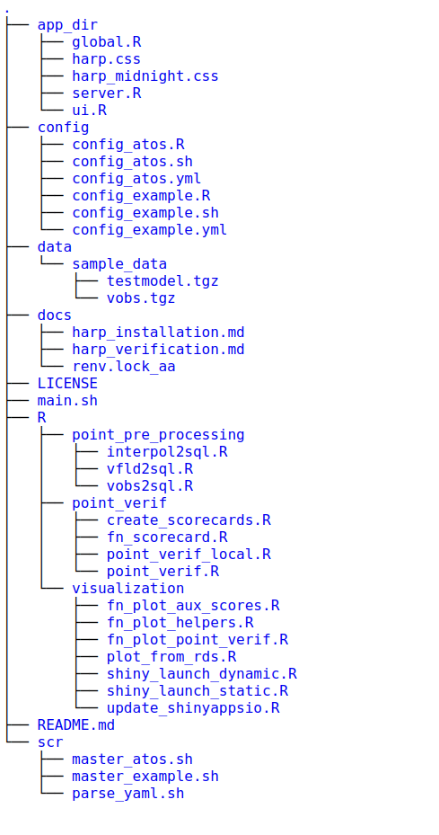

# Configuration and running the scripts

- The scripts need 3 configuration files and one master script.

```
    main.sh (master script)
    config_atos.sh
    config_atos.R
    config_atos.yml
```

- The data processing is split in three steps:
  - pre-processing (generate FCTABLE and OBSTABLE)
  - verification (calculate scores)
  - visualization (visualize using harp or external visapp)
- Recommended: install local R environment using renv.

# renv environment installation

```r
module R
R
renv::init()
exit
```

- Use: `renv:clean()` if the above does not work. Then attempt again.

```r
renv::install("remotes")
library(remotes)
install_github("harphub/harp")
```

- This should give you a local installation in the `renv` directory.
- Check you see this message like this when doing installation:

```bash
Installing package into ‘/etc/ecmwf/nfs/dh1_home_b/nhd/R/dev_accord/accord-verif-scripts/renv/library/R-4.2/x86_64-pc-linux-gnu’
```

- You should see something like this when loading R in the local repository:

```r
- Project '/etc/ecmwf/nfs/dh1_home_b/nhd/R/dev_accord/accord-verif-scripts' loaded. [renv 1.0.3]
- The project is out-of-sync -- use `renv::status()` for details.
[Previously saved workspace restored]
```

# config.sh

- Set some environment variables and decide what steps to do

```bash
#/bin/bash
## load modules
module load R

CONFIG_INITIAL=config_atos

#R Env
USING_RENV=${USING_RENV-no}

export VERIF_DIR=/home/nhd/R/dev_accord/accord-verif-scripts #The location of this repo
export CASE_STUDY=testcase <--- the end path where the results will be written

# What to run
export RUN_POINT_VERF=${RUN_VERF-no} <--- SELECT yes TO PRODUCE rds files ONLY
export RUN_POINT_VERF_LOCAL=${RUN_POINT_VERF_LOCAL-no} <---- SELECT yes to produce png files with different scores

export SCORECARDS=${SCORECARDS-no}  <---  SELECT yes to generate scorecards (not tested yet in v021)
export RUN_VOBS2SQL=${RUN_VOBS2SQL-no} <--- SELECT yes to produce OBSTABLE
export RUN_VFLD2SQL=${RUN_VFLD2SQL-no}  <----SELECT yes to produce FCTABLE

export SHOW_WEB_STATIC=no <---- SELECT yes to display static png files
export SHOW_WEB_DYNAMIC=no   <---- SELECT yes to display harp visualization app that reads the rds files
export SHINY_PORT=3699 # Change this number if port is busy when launching web


## DNOT for USER
MAIN_DIR=$(pwd)
CONFIG_DIR=$MAIN_DIR/config
RS_DIR=$MAIN_DIR/R
CONFIG_YAML=$CONFIG_DIR/$CONFIG_INITIAL.yml
CONFIG_R=$CONFIG_DIR/$CONFIG_INITIAL.R

##
export MAIN_DIR CONFIG_INITIAL
export USING_RENV
export CONFIG_DIR RS_DIR CONFIG_YAML CONFIG_R
```

# config.yml

- Define parameters for verification steps: pre, verification and post

```yaml
#Section to define paths for the pre-processing
# This section will be used by the scripts under pre_processing
shared:
  start_date: 2021010100
  end_date: 2021010123

pre:
  fclen: 24
  vfld_path: "/ec/res4/scratch/nhd/test_data_harp/vfld"
  vobs_path: "/ec/res4/scratch/nhd/test_data_harp/vobs"
  by_vobs_step: "1h"
  vfld_template:  #include one for each model if they are different.
    - "vfld"
  do_all: TRUE # if true, it will ignore list of parameters and do all that is available in the vfld files
  params:
    - S10m
    - T2m
    - RH2m
    - Pmsl
    - T

#Section to define paths for the verification
# This section will be used by the scripts under verification
verif:
  by_step: "12h"
  fcst_model:
    - testmodel #enea43h22mbr000
  lead_time: seq(0, 24, 1)
  fcst_type: "det" #det or eps
  grps: "lead_time"
  fcst_path: "/ec/res4/scratch/nhd/test_data_harp/FCTABLE"
  obs_path: "/ec/res4/scratch/nhd/test_data_harp/OBSTABLE"
  verif_path: "/ec/res4/scratch/nhd/test_data_harp/output/verif_results"

#Section to define the paths for the output
# This section will be used by the plotting scripts
post:
  plot_output: "/ec/res4/scratch/nhd/test_data_harp/output"
  rds_path: "/ec/res4/scratch/smcd/verif_rds"
#This section if only for the scorecards
scorecards:
  ref_model: FC1
  fcst_model: FC2
  params:
    - T2m
    - S10m
    - RH2m
    - Pmsl
```

# config.R

- Define parameters and unit conversions (hard to include this expressions in the yml file)

```r
# Setting up the parameters and their scaling and thresholds here
# Adding this part not so easy using the yml file
# It is possible to create several nested sections like
# variable:
#   - name
#   - threshold
# etc
# but this make look a bit confusing. Hardcoding this part here


# List of parameters
# Add more parameters below using the same format. For upper air parameters,
# don't forget the vc = "pressure"

library(yaml)

conf_get_config <- function(){
  CONFIG <- yaml.load_file(Sys.getenv('CONFIG_YAML') )
  CONFIG$params_details = conf_get_params_details()
  CONFIG
}


conf_get_params_details <- function(){
    T2m_thr <- c(-20, -10, seq(-5, 25, 5))
    S10m_thr <- seq(0, 25, 5)
    RH2m_thr <- seq(0, 100, 20)

    params <- list(
                T2m = list(
        thresholds = T2m_thr,
        scale_fcst = list(scaling = -273.15, new_units = "degC", mult = FALSE),
        scale_obs  = list(scaling = -273.15, new_units = "degC", mult = FALSE)

                        ),

                S10m = list(
        thresholds = S10m_thr

                        ),
         RH2m  =
         list (
        thresholds = RH2m_thr
         ),

                T = list(
        scale_fcst = list(scaling = -273.15, new_units = "degC", mult = FALSE),
        scale_obs  = list(scaling = -273.15, new_units = "degC", mult = FALSE),
        vc         = "pressure"

                        )


              )

    params

}
```

# Example: convert vfld files

```bash
# What to run
export RUN_POINT_VERF=${RUN_VERF-no}
export RUN_POINT_VERF_LOCAL=${RUN_POINT_VERF_LOCAL-no}

export SCORECARDS=${SCORECARDS-no}
export RUN_VOBS2SQL=${RUN_VOBS2SQL-no}
export RUN_VFLD2SQL=${RUN_VFLD2SQL-yes}

export SHOW_WEB_STATIC=no
export SHOW_WEB_DYNAMIC=no
export SHINY_PORT=3699 # Change this number if port is busy when launching web
```

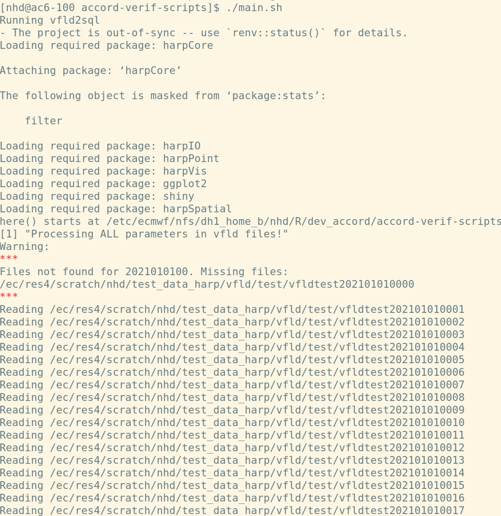

# Scores generation

```bash
# What to run
export RUN_POINT_VERF=${RUN_VERF-yes}
export RUN_POINT_VERF_LOCAL=${RUN_POINT_VERF_LOCAL-yes}

export SCORECARDS=${SCORECARDS-no}
export RUN_VOBS2SQL=${RUN_VOBS2SQL-no}
export RUN_VFLD2SQL=${RUN_VFLD2SQL-no}

export SHOW_WEB_STATIC=no
export SHOW_WEB_DYNAMIC=no
export SHINY_PORT=3699 # Change this number if port is busy when launching web
```

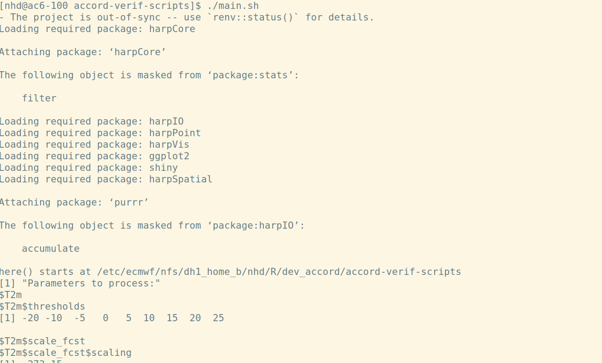

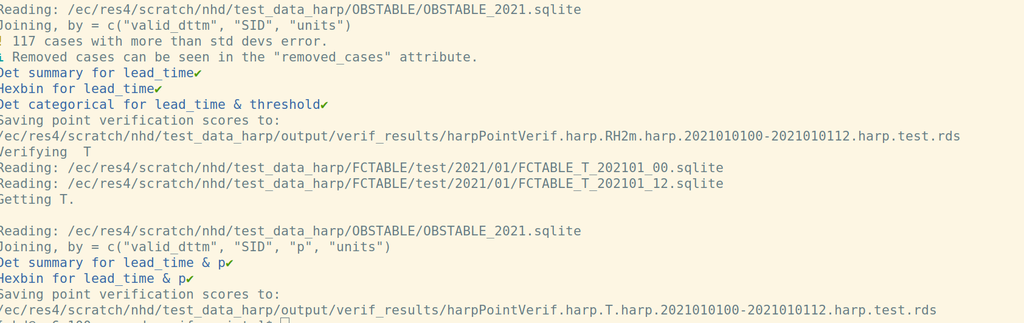

# Visualization using harp

```bash
# What to run
export RUN_POINT_VERF=${RUN_VERF-no}
export RUN_POINT_VERF_LOCAL=${RUN_POINT_VERF_LOCAL-no}

export SCORECARDS=${SCORECARDS-no}
export RUN_VOBS2SQL=${RUN_VOBS2SQL-no}
export RUN_VFLD2SQL=${RUN_VFLD2SQL-no}

export SHOW_WEB_STATIC=no
export SHOW_WEB_DYNAMIC=yes
export SHINY_PORT=3699 # Change this number if port is busy when launching web
```

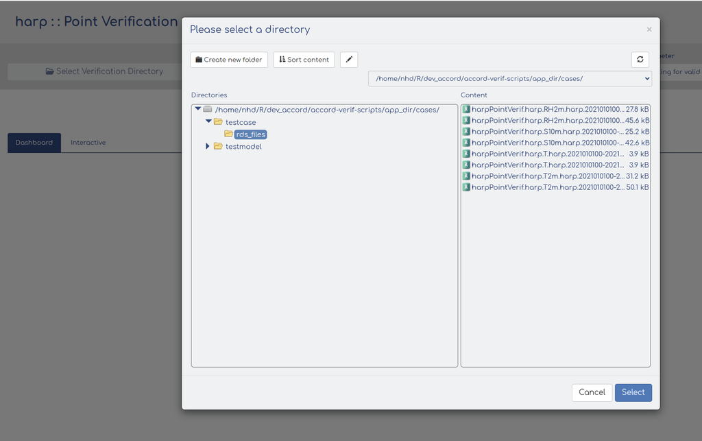

# Example 2

[figure not shown]

# Visualization of static png files (S. Viana)

```bash
# What to run
export RUN_POINT_VERF=${RUN_VERF-no}
export RUN_POINT_VERF_LOCAL=${RUN_POINT_VERF_LOCAL-no}

export SCORECARDS=${SCORECARDS-no}
export RUN_VOBS2SQL=${RUN_VOBS2SQL-no}
export RUN_VFLD2SQL=${RUN_VFLD2SQL-no}

export SHOW_WEB_STATIC=yes
export SHOW_WEB_DYNAMIC=no
export SHINY_PORT=3699 # Change this number if port is busy when launching web
```

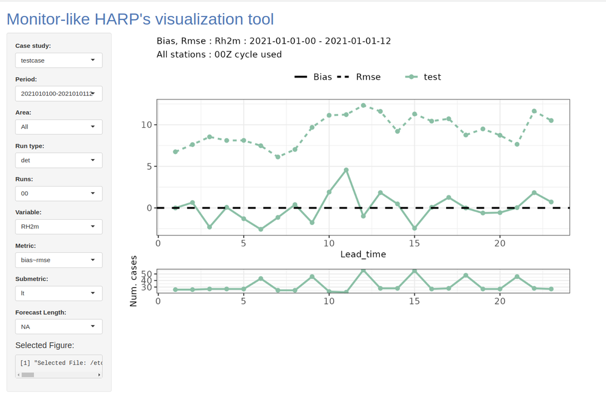